# epidecodeR: an online functional exploration tool for epigenetic and epitranscriptomic regulation

## Introduction

Recent technological advances in chemical modification detection on DNA and RNA using high throughput sequencing have generated a plethora of epigenomic and epitranscriptomic datasets. However, functional characterization of chemical modifications on DNA and RNA still remain largely unexplored. Generally, in silico methods rely on identifying location and quantitative differential analysis of the modifications.

The number of epigenomic/epitranscriptomic modification events associated with the gene can provide the degree of modification/accessibility associated with the gene of interest, which in turn plays a crucial role in determining the levels of differential gene expression. Data integration methods can combine both these layers and provide information about the degree of events occurring and its influence on the differential gene expression, ribosome occupancy or protein translation. We made an assumption that if an epi-mark is functional for up- or down-regulation of expression in a particular context, a gene with the epi-mark is more likely to be impacted for its expression. If a gene has more marked sites thus higher degree of modification would be impacted more, which can be quantified as differential RNA expression, ribosome occupancy, or protein abundance obtained from RNA-seq, Ribo-seq, or proteomics datasets

Here we present epidecodeR, an R package capable of integrating chemical modification data generated from a host of epigenomic or epitranscriptomic techniques such as ChIP-seq, ATAC-seq, m6A-seq, etc. and dysregulated gene lists in the form of differential gene expression, ribosome occupancy or differential protein translation and identify impact of dysregulation of genes caused due to varying degrees of chemical modifications associated with the genes. epidecodeR generates cumulative distribution function (CDF) plots showing shifts in trend of overall log2FC between genes divided into groups based on the degree of modification associated with the genes. The tool also tests for significance of difference in log2FC between groups of genes.

## Implementation steps

1. Calculate sum of all events associated with each gene
2. Group genes into user defined groups based on degree (count) of events per gene
3. Calculate theoretical and empirical cumulative probabilities (quantiles) of log2FC per group
4. Perform ANOVA one-way test of significance in difference of mean between groups
5. Plot CDF plots and boxplot with significance testing results

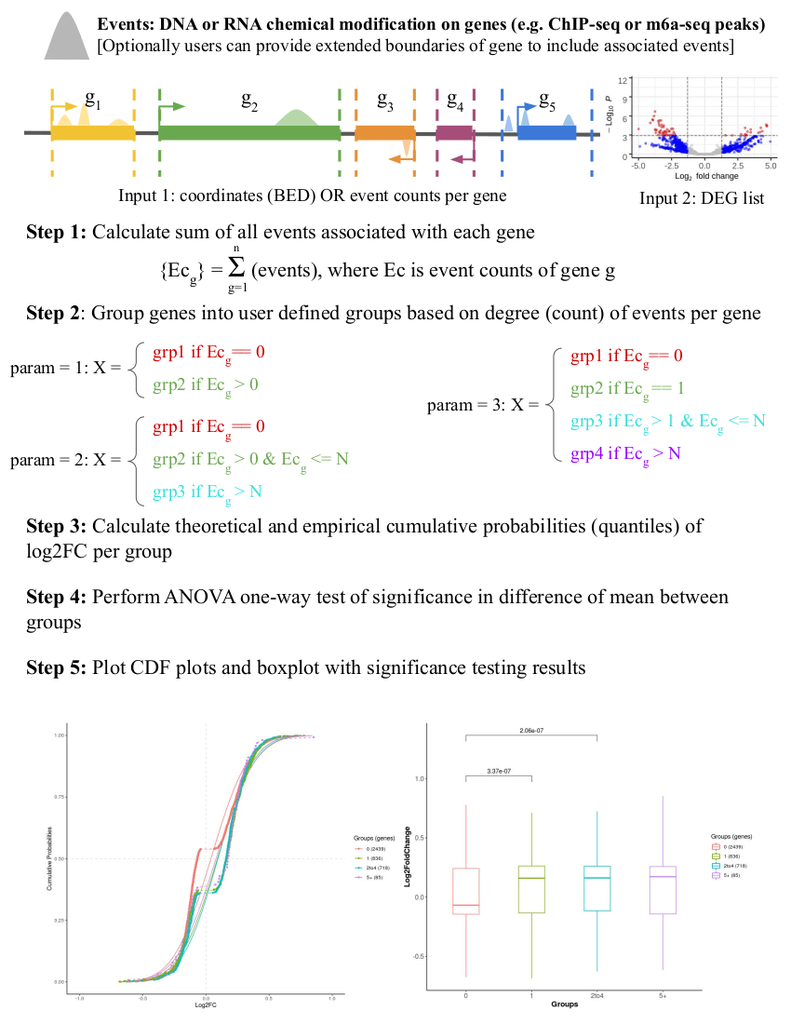

## For the impatient

**Download demo1 files and unzip on local system. demo1.zip contains event counts file and DEG list file.**

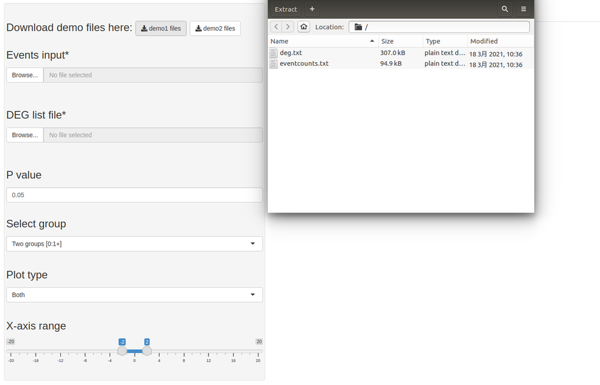

**Upload the files appropriately**

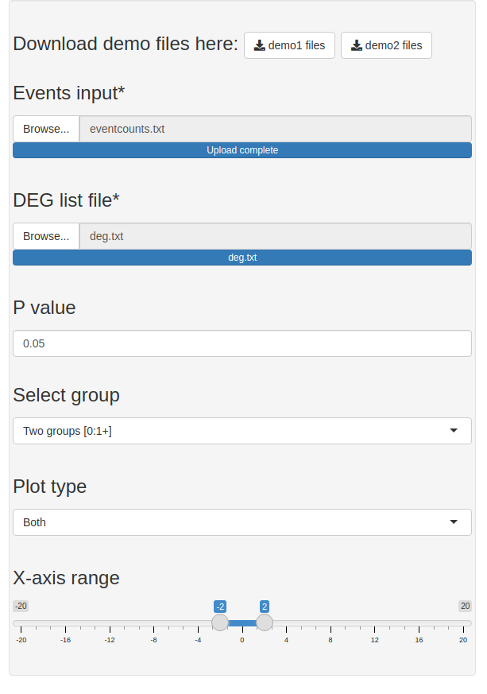

**and… Voilà! The graphs are made in the Renders tab!**

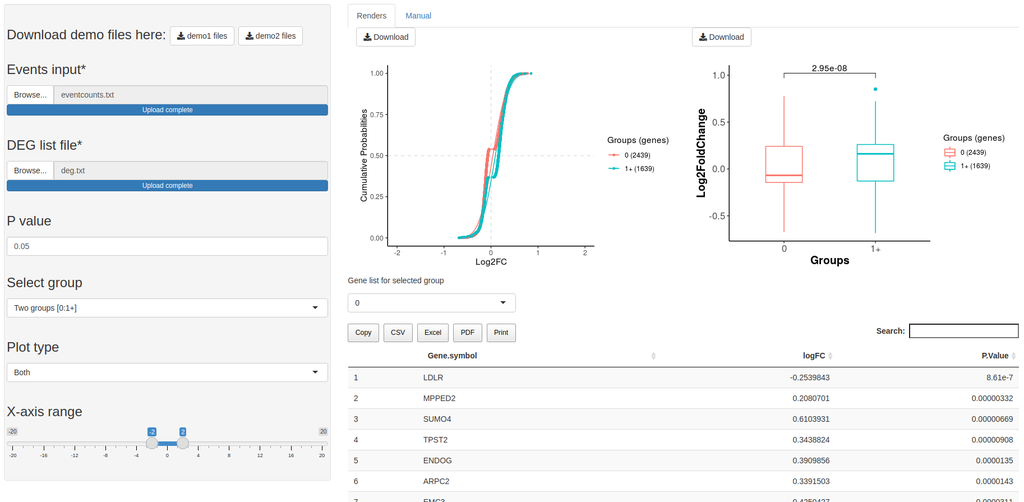

## Details

epidecodeR expects two mandatory inputs:

1. reference events file and
2. dysregulated gene list

Dysregulated genes are divided into groups based on degree of events associated with the respective gene as determined using events file

Event files consist of reference DNA/RNA modification’s genomic positions as a bed file or counts of events (modifications) per gene

Reference modifications are generally modifications identified on wild type cell line or normal (healthy) organism using high throughput sequencing techniques such as ChIP-seq, ATAC-seq, m6A-seq, etc.

Example input files look like this:

Input file as event counts per gene contains two tab (“\t”) separated columns ID and counts and looks like this:

```r
head (eventcounts.txt)
```

```
#>                             ID x
#> 1 ENSMUSG00000025907.14|Rb1cc1 4
#> 2 ENSMUSG00000051285.17|Pcmtd1 2
#> 3    ENSMUSG00000061024.8|Rrs1 2
#> 4   ENSMUSG00000025915.14|Sgk3 1
#> 5  ENSMUSG00000056763.16|Cspp1 2
#> 6  ENSMUSG00000016918.15|Sulf1 2
```

Events as genomic coordinates in BED file format looks like this:

```r
head (NOMO1_ref_peaks.bed)
```

```
#>     V1     V2     V3                 V4      V5 V6     V7     V8 V9 V10    V11
#> 1 chr1 133350 133500  ENSG00000233750.3 1.8e-03  + 133350 133500  0   1   150,
#> 2 chr1 856249 856749  ENSG00000228794.9 1.0e-28  + 856249 856749  0   1   500,
#> 3 chr1 904833 915757  ENSG00000272438.1 1.8e-04  + 904833 915757  0   2 124,8,
#> 4 chr1 912454 913502  ENSG00000230699.2 1.3e-75  + 912454 913502  0   1  1048,
#> 5 chr1 914099 914250  ENSG00000230699.2 3.0e-05  + 914099 914250  0   1   151,
#> 6 chr1 944282 944482 ENSG00000187634.12 3.2e-26  + 944282 944482  0   1   200,
#>       V12
#> 1       0
#> 2       0
#> 3 0,10916
#> 4       0
#> 5       0
#> 6       0
```

BED files must have minimum four columns i.e. chr, start, end and ID columns

**Important: ID of events file and dysregulated gene list must be same. e.g. If ID type in event counts file is gene_id, dysregulated gene list also must have ID type gene_id for successful mapping and groups assignment.**  
[Note: Version of the gene_id must also match e.g. ENSG00000228794.9 & ENSG00000228794.10 not allowed]  
epidecodeR also expects dysregulated gene list as a three column file where 1st column is the ID of the gene (same ID type as the BED/event counts file), 2nd column is the log2FC and 3rd column is the significance of dysregulation (P value or adj P value)

Examples

```r
head (deg.txt)
```

```
#>                        baseMean     lfcSE          padj
#> 1    ENSMUSG00000035299.16|Mid1 -4.928389 5.748620e-188
#> 2  ENSMUSG00000078952.9|Lncenc1 -4.098312 2.980233e-177
#> 3    ENSMUSG00000023087.15|Noct  4.051702 4.301030e-153
#> 4   ENSMUSG00000022816.11|Fstl1 -2.810323 7.630491e-109
#> 5 ENSMUSG00000001435.15|Col18a1 -3.321171 4.935260e-104
#> 6   ENSMUSG00000069045.11|Ddx3y  5.762105 1.136028e-101
```

```r
head (FTOi.txt)
```

```
#>             baseMean         X0 padj
#> 1  ENSG00000244171.4 -0.3729300    1
#> 2  ENSG00000186130.5 -0.3455830    1
#> 3 ENSG00000141736.13 -0.2322570    1
#> 4 ENSG00000115286.20  0.1259070    1
#> 5  ENSG00000121691.7  0.0514218    1
#> 6 ENSG00000159322.17 -0.0676403    1
```

#### arguments

[output not shown]

### Output

epidecodeR tool returns theoretical and empirical cumulative probabilities of the quantiles as well as group information and set of genes belonging to each group. It also calculates one-way ANOVA significance test of difference in means of log2FC between groups following Tukey’s test between every set of two groups, which is depicted as boxplot.

Users can download individual plots using download buttons on top of the respective plots

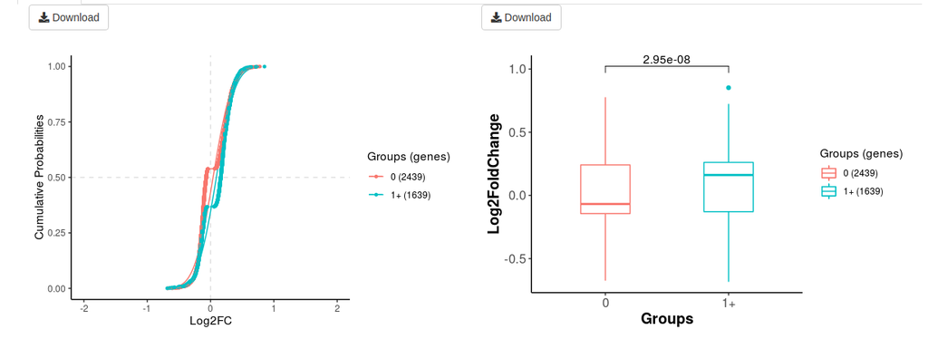

Users can download gene list belonging to group of interest using table download panel

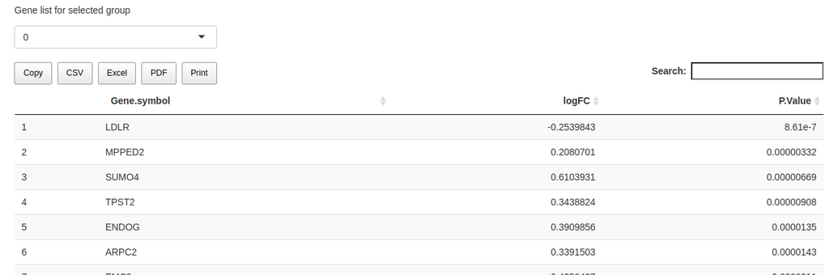

## DIY example

Lets try to make the plots using publicly available data

For this example we will use data from the paper [A Unified Model for the Function of YTHDF Proteins in Regulating m 6 A-Modified mRNA"](https://pubmed.ncbi.nlm.nih.gov/32492408/) by Sara Zaccara & Samie R Jaffrey (PMID 32492408)

Start by downloading the m6A peak counts per gene from the supplementary data of the [paper](https://ars.els-cdn.com/content/image/1-s2.0-S0092867420305742-mmc1.xlsx) or [here](https://github.com/kandarpRJ/kandarprj.github.io/blob/main/1-s2.0-S0092867420305742-mmc1.xlsx)

[figure not shown]

Save the file as a tab separated text file called eventcounts.tsv. Excel or google docs can be used for this purpose.

[figure not shown]

Next, download differental gene expression and differential translational efficiency scores as logFC along with significance value (P value) in response to triple knockdown of m6A readers YTHDF1, YTHDF2 and YTHDF3 versus WT HeLa cells calculated by authors and available for download from GEO [here](https://www.ncbi.nlm.nih.gov/geo/download/?acc=GSE134380&format=file&file=GSE134380%5FRibo%5FGSE134380%5FRNA%5FTE%5FsiDF123%5FHeLa%2Etxt%2Egz)

[figure not shown]

Create differential gene expression list by copying relevant columns to new sheet and save the file as a text file with tab separation.

[figure not shown]

[figure not shown]

If you use different ID types in event counts file and differentila gene list an error will be issued. Please take care to use same ID types between event counts file and differential gene list file

[figure not shown]

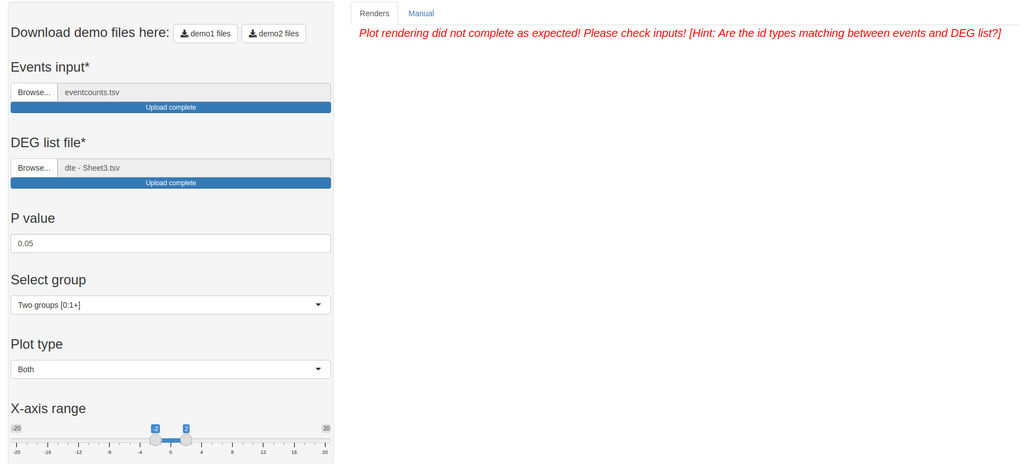

Repeat above steps to create file of differential translational efficiency list.

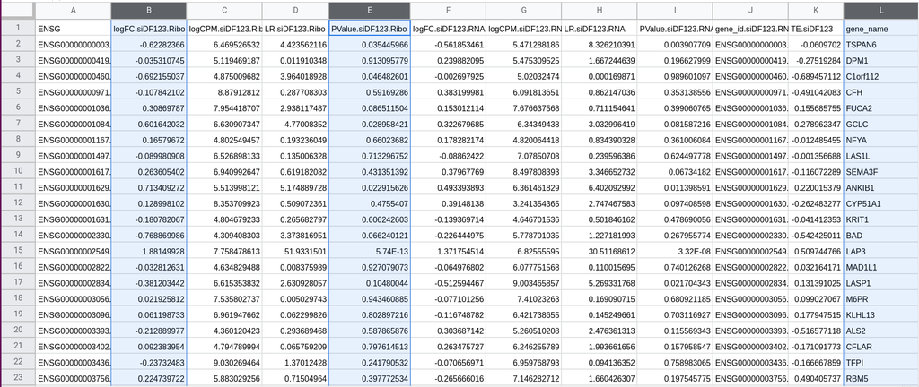

[figure not shown]

[figure not shown]

Now upload the input files to the shiny app and the plots will be generated in the Renders tab.

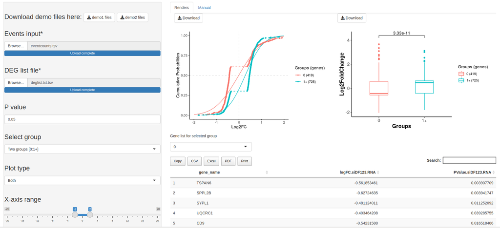

To generate CDF plots for all genes without P value cut off, set P value to 1

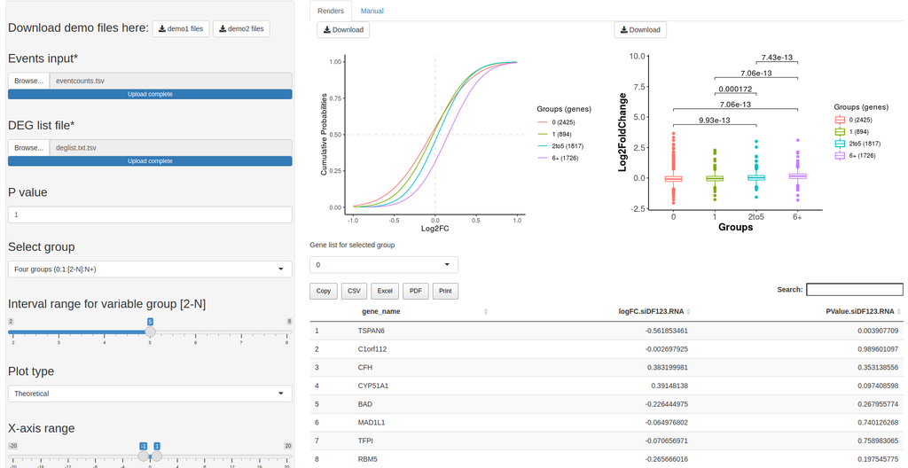